# Risk Factor Analysis

## Outcome Variable

**Outcome Variable:** pers_wast

## Predictor Variables

**Intervention Variable:** enstunt

**Adjustment Set:**

- arm
- sex
- W_mage
- meducyrs
- feducyrs
- vagbrth
- single
- brthmon
- W_parity
- delta_W_mage
- delta_meducyrs
- delta_feducyrs
- delta_vagbrth
- delta_single
- delta_brthmon
- delta_W_parity

## Stratifying Variables

The analysis was stratified on these variable(s):

- agecat
- studyid
- country

## Data Summary

| agecat | studyid | country | enstunt | pers_wast | n_cell | n |
| --- | --- | --- | --- | --- | --- | --- |
| 0-24 months | CMC-V-BCS-2002 | INDIA | 0 | 0 | 281 | 373 |
| 0-24 months | CMC-V-BCS-2002 | INDIA | 0 | 1 | 15 | 373 |
| 0-24 months | CMC-V-BCS-2002 | INDIA | 1 | 0 | 69 | 373 |
| 0-24 months | CMC-V-BCS-2002 | INDIA | 1 | 1 | 8 | 373 |
| 0-24 months | CMIN | BANGLADESH | 0 | 0 | 152 | 257 |
| 0-24 months | CMIN | BANGLADESH | 0 | 1 | 9 | 257 |
| 0-24 months | CMIN | BANGLADESH | 1 | 0 | 85 | 257 |
| 0-24 months | CMIN | BANGLADESH | 1 | 1 | 11 | 257 |
| 0-24 months | COHORTS | GUATEMALA | 0 | 0 | 826 | 1056 |
| 0-24 months | COHORTS | GUATEMALA | 0 | 1 | 22 | 1056 |
| 0-24 months | COHORTS | GUATEMALA | 1 | 0 | 194 | 1056 |
| 0-24 months | COHORTS | GUATEMALA | 1 | 1 | 14 | 1056 |
| 0-24 months | COHORTS | INDIA | 0 | 0 | 4663 | 5705 |
| 0-24 months | COHORTS | INDIA | 0 | 1 | 447 | 5705 |
| 0-24 months | COHORTS | INDIA | 1 | 0 | 492 | 5705 |
| 0-24 months | COHORTS | INDIA | 1 | 1 | 103 | 5705 |
| 0-24 months | COHORTS | PHILIPPINES | 0 | 0 | 2524 | 2811 |
| 0-24 months | COHORTS | PHILIPPINES | 0 | 1 | 127 | 2811 |
| 0-24 months | COHORTS | PHILIPPINES | 1 | 0 | 143 | 2811 |
| 0-24 months | COHORTS | PHILIPPINES | 1 | 1 | 17 | 2811 |
| 0-24 months | CONTENT | PERU | 0 | 0 | 195 | 215 |
| 0-24 months | CONTENT | PERU | 0 | 1 | 0 | 215 |
| 0-24 months | CONTENT | PERU | 1 | 0 | 20 | 215 |
| 0-24 months | CONTENT | PERU | 1 | 1 | 0 | 215 |
| 0-24 months | EE | PAKISTAN | 0 | 0 | 195 | 377 |
| 0-24 months | EE | PAKISTAN | 0 | 1 | 16 | 377 |
| 0-24 months | EE | PAKISTAN | 1 | 0 | 149 | 377 |
| 0-24 months | EE | PAKISTAN | 1 | 1 | 17 | 377 |
| 0-24 months | GMS-Nepal | NEPAL | 0 | 0 | 434 | 597 |
| 0-24 months | GMS-Nepal | NEPAL | 0 | 1 | 66 | 597 |

[output cut: 94 more lines]

The following strata were considered:

- agecat: 0-24 months, studyid: CMC-V-BCS-2002, country: INDIA
- agecat: 0-24 months, studyid: CMIN, country: BANGLADESH
- agecat: 0-24 months, studyid: COHORTS, country: GUATEMALA
- agecat: 0-24 months, studyid: COHORTS, country: INDIA
- agecat: 0-24 months, studyid: COHORTS, country: PHILIPPINES
- agecat: 0-24 months, studyid: CONTENT, country: PERU
- agecat: 0-24 months, studyid: EE, country: PAKISTAN
- agecat: 0-24 months, studyid: GMS-Nepal, country: NEPAL
- agecat: 0-24 months, studyid: Guatemala BSC, country: GUATEMALA
- agecat: 0-24 months, studyid: iLiNS-Zinc, country: BURKINA FASO
- agecat: 0-24 months, studyid: IRC, country: INDIA
- agecat: 0-24 months, studyid: JiVitA-3, country: BANGLADESH
- agecat: 0-24 months, studyid: JiVitA-4, country: BANGLADESH
- agecat: 0-24 months, studyid: Keneba, country: GAMBIA
- agecat: 0-24 months, studyid: LCNI-5, country: MALAWI
- agecat: 0-24 months, studyid: MAL-ED, country: BANGLADESH
- agecat: 0-24 months, studyid: MAL-ED, country: BRAZIL
- agecat: 0-24 months, studyid: MAL-ED, country: INDIA
- agecat: 0-24 months, studyid: MAL-ED, country: NEPAL
- agecat: 0-24 months, studyid: MAL-ED, country: PERU
- agecat: 0-24 months, studyid: MAL-ED, country: SOUTH AFRICA
- agecat: 0-24 months, studyid: MAL-ED, country: TANZANIA, UNITED REPUBLIC OF
- agecat: 0-24 months, studyid: NIH-Birth, country: BANGLADESH
- agecat: 0-24 months, studyid: NIH-Crypto, country: BANGLADESH
- agecat: 0-24 months, studyid: PROBIT, country: BELARUS
- agecat: 0-24 months, studyid: PROVIDE, country: BANGLADESH
- agecat: 0-24 months, studyid: ResPak, country: PAKISTAN
- agecat: 0-24 months, studyid: SAS-CompFeed, country: INDIA
- agecat: 0-24 months, studyid: SAS-FoodSuppl, country: INDIA
- agecat: 0-24 months, studyid: TanzaniaChild2, country: TANZANIA, UNITED REPUBLIC OF
- agecat: 0-24 months, studyid: ZVITAMBO, country: ZIMBABWE

### Dropped Strata

Some strata were dropped due to rare outcomes:

- agecat: 0-24 months, studyid: CONTENT, country: PERU
- agecat: 0-24 months, studyid: Guatemala BSC, country: GUATEMALA
- agecat: 0-24 months, studyid: LCNI-5, country: MALAWI
- agecat: 0-24 months, studyid: MAL-ED, country: BANGLADESH
- agecat: 0-24 months, studyid: MAL-ED, country: BRAZIL
- agecat: 0-24 months, studyid: MAL-ED, country: INDIA
- agecat: 0-24 months, studyid: MAL-ED, country: NEPAL
- agecat: 0-24 months, studyid: MAL-ED, country: PERU
- agecat: 0-24 months, studyid: MAL-ED, country: SOUTH AFRICA
- agecat: 0-24 months, studyid: MAL-ED, country: TANZANIA, UNITED REPUBLIC OF
- agecat: 0-24 months, studyid: PROBIT, country: BELARUS
- agecat: 0-24 months, studyid: PROVIDE, country: BANGLADESH
- agecat: 0-24 months, studyid: TanzaniaChild2, country: TANZANIA, UNITED REPUBLIC OF

## Methods Detail

We're interested in the causal parameters $E[Y_a]$ for all values of $a \in \mathcal{A}$. These parameters represent the mean outcome if, possibly contrary to fact, we intervened to set all units to have $A=a$. Under the randomization and positivity assumptions, these are identified by the statistical parameters $\psi_a=E_W[E_{Y|A,W}(Y|A=a,W)]$. In addition, we're interested in the mean of $Y$, $E[Y]$ under no intervention (the observed mean). We will estimate these parameters by using SuperLearner to fit the relevant likelihood factors -- $E_{Y|A,W}(Y|A=a,W)$ and $p(A=a|W)$, and then updating our likelihood fit using a joint TMLE.

For unadjusted analyses ($W=\{\}$), initial likelihoods were estimated using Lrnr_glm to estimate the simple $E(Y|A)$ and Lrnr_mean to estimate $p(A)$. For adjusted analyses, a small library containing Lrnr_glmnet, Lrnr_xgboost, and Lrnr_mean was used.

Having estimated these parameters, we will then use the delta method to estimate relative risks and attributable risks relative to a prespecified baseline level of $A$.

# Results Detail

## Results Plots

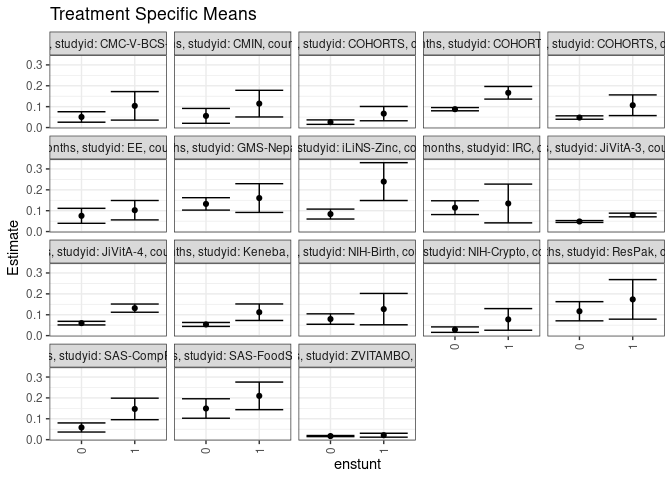

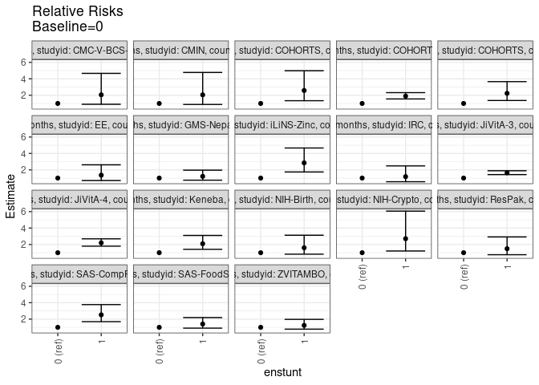

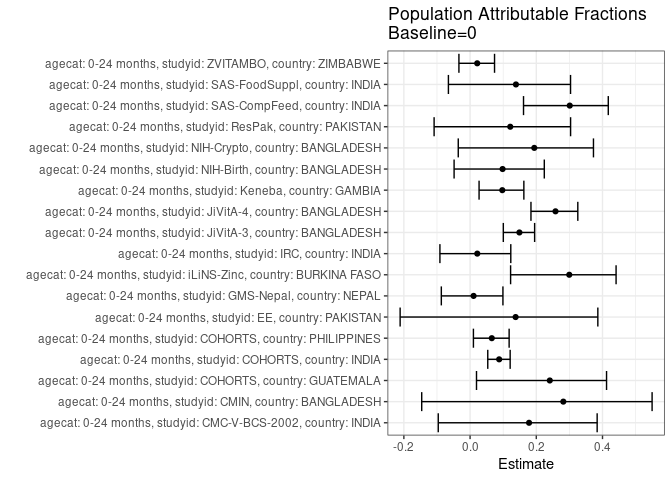

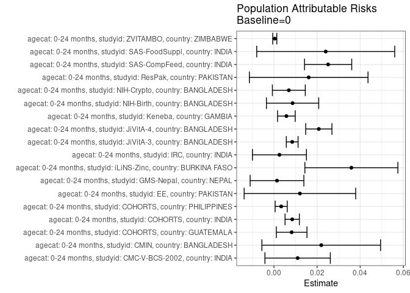

## Results Table

### Parameter: TSM

| agecat | studyid | country | intervention_level | baseline_level | estimate | ci_lower | ci_upper |
| --- | --- | --- | --- | --- | --- | --- | --- |
| 0-24 months | CMC-V-BCS-2002 | INDIA | 0 | NA | 0.0506757 | 0.0256554 | 0.0756960 |
| 0-24 months | CMC-V-BCS-2002 | INDIA | 1 | NA | 0.1038961 | 0.0356521 | 0.1721401 |
| 0-24 months | CMIN | BANGLADESH | 0 | NA | 0.0559006 | 0.0203458 | 0.0914555 |
| 0-24 months | CMIN | BANGLADESH | 1 | NA | 0.1145833 | 0.0507432 | 0.1784234 |
| 0-24 months | COHORTS | GUATEMALA | 0 | NA | 0.0258820 | 0.0152010 | 0.0365631 |
| 0-24 months | COHORTS | GUATEMALA | 1 | NA | 0.0667411 | 0.0325013 | 0.1009809 |
| 0-24 months | COHORTS | INDIA | 0 | NA | 0.0879370 | 0.0801887 | 0.0956853 |
| 0-24 months | COHORTS | INDIA | 1 | NA | 0.1665438 | 0.1363395 | 0.1967481 |
| 0-24 months | COHORTS | PHILIPPINES | 0 | NA | 0.0478678 | 0.0397363 | 0.0559993 |
| 0-24 months | COHORTS | PHILIPPINES | 1 | NA | 0.1068247 | 0.0572704 | 0.1563790 |
| 0-24 months | EE | PAKISTAN | 0 | NA | 0.0754945 | 0.0395839 | 0.1114051 |
| 0-24 months | EE | PAKISTAN | 1 | NA | 0.1023595 | 0.0558983 | 0.1488207 |
| 0-24 months | GMS-Nepal | NEPAL | 0 | NA | 0.1325896 | 0.1028846 | 0.1622946 |
| 0-24 months | GMS-Nepal | NEPAL | 1 | NA | 0.1605303 | 0.0916564 | 0.2294043 |
| 0-24 months | iLiNS-Zinc | BURKINA FASO | 0 | NA | 0.0839327 | 0.0602019 | 0.1076634 |
| 0-24 months | iLiNS-Zinc | BURKINA FASO | 1 | NA | 0.2393804 | 0.1486908 | 0.3300700 |
| 0-24 months | IRC | INDIA | 0 | NA | 0.1145251 | 0.0814977 | 0.1475526 |
| 0-24 months | IRC | INDIA | 1 | NA | 0.1346154 | 0.0417340 | 0.2274968 |
| 0-24 months | JiVitA-3 | BANGLADESH | 0 | NA | 0.0483577 | 0.0438401 | 0.0528754 |
| 0-24 months | JiVitA-3 | BANGLADESH | 1 | NA | 0.0794873 | 0.0706627 | 0.0883119 |
| 0-24 months | JiVitA-4 | BANGLADESH | 0 | NA | 0.0598536 | 0.0512150 | 0.0684923 |
| 0-24 months | JiVitA-4 | BANGLADESH | 1 | NA | 0.1315992 | 0.1119679 | 0.1512305 |
| 0-24 months | Keneba | GAMBIA | 0 | NA | 0.0535547 | 0.0441350 | 0.0629744 |
| 0-24 months | Keneba | GAMBIA | 1 | NA | 0.1120558 | 0.0725671 | 0.1515446 |
| 0-24 months | NIH-Birth | BANGLADESH | 0 | NA | 0.0793735 | 0.0543852 | 0.1043617 |
| 0-24 months | NIH-Birth | BANGLADESH | 1 | NA | 0.1270232 | 0.0519091 | 0.2021373 |
| 0-24 months | NIH-Crypto | BANGLADESH | 0 | NA | 0.0287081 | 0.0156287 | 0.0417876 |
| 0-24 months | NIH-Crypto | BANGLADESH | 1 | NA | 0.0776699 | 0.0259454 | 0.1293945 |
| 0-24 months | ResPak | PAKISTAN | 0 | NA | 0.1166997 | 0.0707497 | 0.1626497 |
| 0-24 months | ResPak | PAKISTAN | 1 | NA | 0.1735115 | 0.0787641 | 0.2682590 |
| 0-24 months | SAS-CompFeed | INDIA | 0 | NA | 0.0583306 | 0.0365440 | 0.0801172 |
| 0-24 months | SAS-CompFeed | INDIA | 1 | NA | 0.1471322 | 0.0956230 | 0.1986413 |
| 0-24 months | SAS-FoodSuppl | INDIA | 0 | NA | 0.1493231 | 0.1027310 | 0.1959153 |
| 0-24 months | SAS-FoodSuppl | INDIA | 1 | NA | 0.2097520 | 0.1436891 | 0.2758149 |
| 0-24 months | ZVITAMBO | ZIMBABWE | 0 | NA | 0.0172538 | 0.0145000 | 0.0200077 |
| 0-24 months | ZVITAMBO | ZIMBABWE | 1 | NA | 0.0213808 | 0.0120766 | 0.0306850 |

### Parameter: E(Y)

| agecat | studyid | country | intervention_level | baseline_level | estimate | ci_lower | ci_upper |
| --- | --- | --- | --- | --- | --- | --- | --- |
| 0-24 months | CMC-V-BCS-2002 | INDIA | NA | NA | 0.0616622 | 0.0372186 | 0.0861058 |
| 0-24 months | CMIN | BANGLADESH | NA | NA | 0.0778210 | 0.0450051 | 0.1106369 |
| 0-24 months | COHORTS | GUATEMALA | NA | NA | 0.0340909 | 0.0231410 | 0.0450408 |
| 0-24 months | COHORTS | INDIA | NA | NA | 0.0964067 | 0.0887472 | 0.1040661 |
| 0-24 months | COHORTS | PHILIPPINES | NA | NA | 0.0512273 | 0.0430760 | 0.0593786 |
| 0-24 months | EE | PAKISTAN | NA | NA | 0.0875332 | 0.0589672 | 0.1160991 |
| 0-24 months | GMS-Nepal | NEPAL | NA | NA | 0.1340034 | 0.1066544 | 0.1613523 |
| 0-24 months | iLiNS-Zinc | BURKINA FASO | NA | NA | 0.1198322 | 0.0943748 | 0.1452897 |
| 0-24 months | IRC | INDIA | NA | NA | 0.1170732 | 0.0859146 | 0.1482317 |
| 0-24 months | JiVitA-3 | BANGLADESH | NA | NA | 0.0568247 | 0.0527145 | 0.0609348 |
| 0-24 months | JiVitA-4 | BANGLADESH | NA | NA | 0.0806665 | 0.0720540 | 0.0892791 |
| 0-24 months | Keneba | GAMBIA | NA | NA | 0.0593290 | 0.0499611 | 0.0686968 |
| 0-24 months | NIH-Birth | BANGLADESH | NA | NA | 0.0880150 | 0.0639627 | 0.1120673 |
| 0-24 months | NIH-Crypto | BANGLADESH | NA | NA | 0.0356164 | 0.0221630 | 0.0490699 |
| 0-24 months | ResPak | PAKISTAN | NA | NA | 0.1328125 | 0.0911588 | 0.1744662 |
| 0-24 months | SAS-CompFeed | INDIA | NA | NA | 0.0834553 | 0.0601989 | 0.1067118 |
| 0-24 months | SAS-FoodSuppl | INDIA | NA | NA | 0.1733333 | 0.1349698 | 0.2116969 |
| 0-24 months | ZVITAMBO | ZIMBABWE | NA | NA | 0.0176341 | 0.0149910 | 0.0202771 |

### Parameter: RR

| agecat | studyid | country | intervention_level | baseline_level | estimate | ci_lower | ci_upper |
| --- | --- | --- | --- | --- | --- | --- | --- |
| 0-24 months | CMC-V-BCS-2002 | INDIA | 0 | 0 | 1.000000 | 1.0000000 | 1.000000 |
| 0-24 months | CMC-V-BCS-2002 | INDIA | 1 | 0 | 2.050216 | 0.9014289 | 4.663027 |
| 0-24 months | CMIN | BANGLADESH | 0 | 0 | 1.000000 | 1.0000000 | 1.000000 |
| 0-24 months | CMIN | BANGLADESH | 1 | 0 | 2.049768 | 0.8800068 | 4.774453 |
| 0-24 months | COHORTS | GUATEMALA | 0 | 0 | 1.000000 | 1.0000000 | 1.000000 |
| 0-24 months | COHORTS | GUATEMALA | 1 | 0 | 2.578666 | 1.3348830 | 4.981348 |
| 0-24 months | COHORTS | INDIA | 0 | 0 | 1.000000 | 1.0000000 | 1.000000 |
| 0-24 months | COHORTS | INDIA | 1 | 0 | 1.893899 | 1.5485120 | 2.316323 |
| 0-24 months | COHORTS | PHILIPPINES | 0 | 0 | 1.000000 | 1.0000000 | 1.000000 |
| 0-24 months | COHORTS | PHILIPPINES | 1 | 0 | 2.231661 | 1.3617120 | 3.657389 |
| 0-24 months | EE | PAKISTAN | 0 | 0 | 1.000000 | 1.0000000 | 1.000000 |
| 0-24 months | EE | PAKISTAN | 1 | 0 | 1.355854 | 0.7022855 | 2.617654 |
| 0-24 months | GMS-Nepal | NEPAL | 0 | 0 | 1.000000 | 1.0000000 | 1.000000 |
| 0-24 months | GMS-Nepal | NEPAL | 1 | 0 | 1.210731 | 0.7454455 | 1.966434 |
| 0-24 months | iLiNS-Zinc | BURKINA FASO | 0 | 0 | 1.000000 | 1.0000000 | 1.000000 |
| 0-24 months | iLiNS-Zinc | BURKINA FASO | 1 | 0 | 2.852053 | 1.7449651 | 4.661530 |
| 0-24 months | IRC | INDIA | 0 | 0 | 1.000000 | 1.0000000 | 1.000000 |
| 0-24 months | IRC | INDIA | 1 | 0 | 1.175422 | 0.5564423 | 2.482948 |
| 0-24 months | JiVitA-3 | BANGLADESH | 0 | 0 | 1.000000 | 1.0000000 | 1.000000 |
| 0-24 months | JiVitA-3 | BANGLADESH | 1 | 0 | 1.643736 | 1.4266896 | 1.893802 |
| 0-24 months | JiVitA-4 | BANGLADESH | 0 | 0 | 1.000000 | 1.0000000 | 1.000000 |
| 0-24 months | JiVitA-4 | BANGLADESH | 1 | 0 | 2.198684 | 1.7983370 | 2.688156 |
| 0-24 months | Keneba | GAMBIA | 0 | 0 | 1.000000 | 1.0000000 | 1.000000 |
| 0-24 months | Keneba | GAMBIA | 1 | 0 | 2.092363 | 1.4113961 | 3.101880 |
| 0-24 months | NIH-Birth | BANGLADESH | 0 | 0 | 1.000000 | 1.0000000 | 1.000000 |
| 0-24 months | NIH-Birth | BANGLADESH | 1 | 0 | 1.600323 | 0.8188272 | 3.127684 |
| 0-24 months | NIH-Crypto | BANGLADESH | 0 | 0 | 1.000000 | 1.0000000 | 1.000000 |
| 0-24 months | NIH-Crypto | BANGLADESH | 1 | 0 | 2.705502 | 1.2073171 | 6.062814 |
| 0-24 months | ResPak | PAKISTAN | 0 | 0 | 1.000000 | 1.0000000 | 1.000000 |
| 0-24 months | ResPak | PAKISTAN | 1 | 0 | 1.486821 | 0.7569871 | 2.920310 |
| 0-24 months | SAS-CompFeed | INDIA | 0 | 0 | 1.000000 | 1.0000000 | 1.000000 |
| 0-24 months | SAS-CompFeed | INDIA | 1 | 0 | 2.522383 | 1.6889474 | 3.767089 |
| 0-24 months | SAS-FoodSuppl | INDIA | 0 | 0 | 1.000000 | 1.0000000 | 1.000000 |
| 0-24 months | SAS-FoodSuppl | INDIA | 1 | 0 | 1.404685 | 0.9017577 | 2.188105 |
| 0-24 months | ZVITAMBO | ZIMBABWE | 0 | 0 | 1.000000 | 1.0000000 | 1.000000 |
| 0-24 months | ZVITAMBO | ZIMBABWE | 1 | 0 | 1.239194 | 0.7795730 | 1.969798 |

### Parameter: PAR

| agecat | studyid | country | intervention_level | baseline_level | estimate | ci_lower | ci_upper |
| --- | --- | --- | --- | --- | --- | --- | --- |
| 0-24 months | CMC-V-BCS-2002 | INDIA | 0 | NA | 0.0109865 | -0.0041772 | 0.0261502 |
| 0-24 months | CMIN | BANGLADESH | 0 | NA | 0.0219204 | -0.0055961 | 0.0494369 |
| 0-24 months | COHORTS | GUATEMALA | 0 | NA | 0.0082089 | 0.0011049 | 0.0153129 |
| 0-24 months | COHORTS | INDIA | 0 | NA | 0.0084697 | 0.0051502 | 0.0117891 |
| 0-24 months | COHORTS | PHILIPPINES | 0 | NA | 0.0033595 | 0.0005526 | 0.0061665 |
| 0-24 months | EE | PAKISTAN | 0 | NA | 0.0120387 | -0.0138232 | 0.0379005 |
| 0-24 months | GMS-Nepal | NEPAL | 0 | NA | 0.0014137 | -0.0110403 | 0.0138677 |
| 0-24 months | iLiNS-Zinc | BURKINA FASO | 0 | NA | 0.0358996 | 0.0143412 | 0.0574580 |
| 0-24 months | IRC | INDIA | 0 | NA | 0.0025480 | -0.0099714 | 0.0150675 |
| 0-24 months | JiVitA-3 | BANGLADESH | 0 | NA | 0.0084669 | 0.0057431 | 0.0111908 |
| 0-24 months | JiVitA-4 | BANGLADESH | 0 | NA | 0.0208129 | 0.0147339 | 0.0268919 |
| 0-24 months | Keneba | GAMBIA | 0 | NA | 0.0057743 | 0.0016778 | 0.0098707 |
| 0-24 months | NIH-Birth | BANGLADESH | 0 | NA | 0.0086415 | -0.0034842 | 0.0207672 |
| 0-24 months | NIH-Crypto | BANGLADESH | 0 | NA | 0.0069083 | -0.0007205 | 0.0145371 |
| 0-24 months | ResPak | PAKISTAN | 0 | NA | 0.0161128 | -0.0113951 | 0.0436208 |
| 0-24 months | SAS-CompFeed | INDIA | 0 | NA | 0.0251247 | 0.0141754 | 0.0360740 |
| 0-24 months | SAS-FoodSuppl | INDIA | 0 | NA | 0.0240102 | -0.0079825 | 0.0560029 |
| 0-24 months | ZVITAMBO | ZIMBABWE | 0 | NA | 0.0003803 | -0.0005697 | 0.0013302 |

### Parameter: PAF

| agecat | studyid | country | intervention_level | baseline_level | estimate | ci_lower | ci_upper |
| --- | --- | --- | --- | --- | --- | --- | --- |
| 0-24 months | CMC-V-BCS-2002 | INDIA | 0 | NA | 0.1781727 | -0.0961308 | 0.3838326 |
| 0-24 months | CMIN | BANGLADESH | 0 | NA | 0.2816770 | -0.1460941 | 0.5497857 |
| 0-24 months | COHORTS | GUATEMALA | 0 | NA | 0.2407938 | 0.0193934 | 0.4122066 |
| 0-24 months | COHORTS | INDIA | 0 | NA | 0.0878535 | 0.0534102 | 0.1210435 |
| 0-24 months | COHORTS | PHILIPPINES | 0 | NA | 0.0655807 | 0.0100848 | 0.1179655 |
| 0-24 months | EE | PAKISTAN | 0 | NA | 0.1375326 | -0.2112715 | 0.3858933 |
| 0-24 months | GMS-Nepal | NEPAL | 0 | NA | 0.0105501 | -0.0868482 | 0.0992199 |
| 0-24 months | iLiNS-Zinc | BURKINA FASO | 0 | NA | 0.2995819 | 0.1224047 | 0.4409889 |
| 0-24 months | IRC | INDIA | 0 | NA | 0.0217644 | -0.0911067 | 0.1229595 |
| 0-24 months | JiVitA-3 | BANGLADESH | 0 | NA | 0.1490010 | 0.1004021 | 0.1949744 |
| 0-24 months | JiVitA-4 | BANGLADESH | 0 | NA | 0.2580116 | 0.1838956 | 0.3253967 |
| 0-24 months | Keneba | GAMBIA | 0 | NA | 0.0973265 | 0.0271568 | 0.1624349 |
| 0-24 months | NIH-Birth | BANGLADESH | 0 | NA | 0.0981823 | -0.0482756 | 0.2241781 |
| 0-24 months | NIH-Crypto | BANGLADESH | 0 | NA | 0.1939639 | -0.0356867 | 0.3726924 |
| 0-24 months | ResPak | PAKISTAN | 0 | NA | 0.1213201 | -0.1086579 | 0.3035918 |
| 0-24 months | SAS-CompFeed | INDIA | 0 | NA | 0.3010559 | 0.1614149 | 0.4174439 |
| 0-24 months | SAS-FoodSuppl | INDIA | 0 | NA | 0.1385204 | -0.0654446 | 0.3034391 |
| 0-24 months | ZVITAMBO | ZIMBABWE | 0 | NA | 0.0215640 | -0.0337132 | 0.0738852 |